# Lasso-and-Ridge

Jeetendra Gan

10/12/2019

Loading the ElemStatLearn, and glmnet packages.

```r
library(ElemStatLearn)
library(glmnet)
```

We will be using the prostate data

```r
data(prostate)
head(prostate)
```

```
##       lcavol  lweight age      lbph svi       lcp gleason pgg45       lpsa
## 1 -0.5798185 2.769459  50 -1.386294   0 -1.386294       6     0 -0.4307829
## 2 -0.9942523 3.319626  58 -1.386294   0 -1.386294       6     0 -0.1625189
## 3 -0.5108256 2.691243  74 -1.386294   0 -1.386294       7    20 -0.1625189
## 4 -1.2039728 3.282789  58 -1.386294   0 -1.386294       6     0 -0.1625189
## 5  0.7514161 3.432373  62 -1.386294   0 -1.386294       6     0  0.3715636
## 6 -1.0498221 3.228826  50 -1.386294   0 -1.386294       6     0  0.7654678
##   train
## 1  TRUE
## 2  TRUE
## 3  TRUE
## 4  TRUE
## 5  TRUE
## 6  TRUE
```

Omitting the train column as it is a dummy column. The response variable is lpsa. Dividing the training data into two parts, relavent predictors and the response.

```r
# this is the relavent data, excluding the train predictor
my_datas <- na.omit(prostate[, 1:9])
X <- as.matrix(my_datas[, 1:8])
Y <- my_datas[, 9]
```

Here is the set of predictors

```r
head(X)
```

```
##       lcavol  lweight age      lbph svi       lcp gleason pgg45
## 1 -0.5798185 2.769459  50 -1.386294   0 -1.386294       6     0
## 2 -0.9942523 3.319626  58 -1.386294   0 -1.386294       6     0
## 3 -0.5108256 2.691243  74 -1.386294   0 -1.386294       7    20
## 4 -1.2039728 3.282789  58 -1.386294   0 -1.386294       6     0
## 5  0.7514161 3.432373  62 -1.386294   0 -1.386294       6     0
## 6 -1.0498221 3.228826  50 -1.386294   0 -1.386294       6     0
```

And, here is the response head

```r
head(Y)
```

```
## [1] -0.4307829 -0.1625189 -0.1625189 -0.1625189  0.3715636  0.7654678
```

## Fitting a ridge regression model

```r
ridge.mod = glmnet(X, Y, alpha = 0)
names(ridge.mod)
```

```
##  [1] "a0"        "beta"      "df"        "dim"       "lambda"
##  [6] "dev.ratio" "nulldev"   "npasses"   "jerr"      "offset"
## [11] "call"      "nobs"
```

We have 9*100 = 900 coefficients, because we have 100 values of lambda.

```r
dim(coef(ridge.mod))
```

```
## [1]   9 100
```

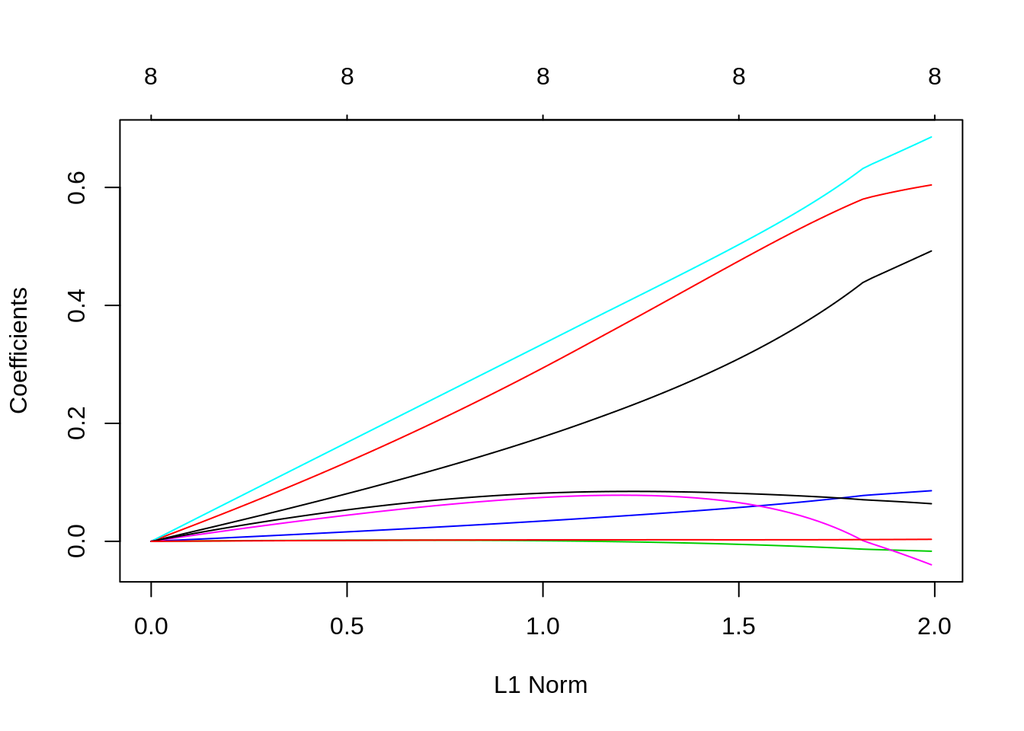

```r
plot(ridge.mod)
```

The rows represent the coefficients and the 100 columns represent different lambda values. So, let us select coefficients for some value of lambda.

```r
print(paste("Below are the coefficients for the lambda : ",ridge.mod$lambda[10]))
```

```
## [1] "Below are the coefficients for the lambda :  365.09960409933"
```

```r
coef10 = coef(ridge.mod)[, 10]
print(paste("Largest value of Lambda is: ", ridge.mod$lambda[1]))
```

```
## [1] "Largest value of Lambda is:  843.427438260761"
```

```r
print(paste("Smallest value of Lambda is: ", ridge.mod$lambda[100]))
```

```
## [1] "Smallest value of Lambda is:  0.0843427445495512"
```

```r
print(paste("So, the smallest value will be closest to the least squares solution."))
```

```
## [1] "So, the smallest value will be closest to the least squares solution."
```

We can use the predict method to get coefficients of any lambda value we like.

```r
predict(ridge.mod, s = 0.005, type = "coefficient")
```

```
## 9 x 1 sparse Matrix of class "dgCMatrix"
##                        1
## (Intercept)  0.011566730
## lcavol       0.492211875
## lweight      0.604155671
## age         -0.016727236
## lbph         0.085820464
## svi          0.685477645
## lcp         -0.039717080
## gleason      0.063806235
## pgg45        0.003411982
```

### Model Selection

```r
set.seed(12345)
train <- sample(1:nrow(X), round(nrow(X)/2))
```

Will do validation now

```r
cvFit = cv.glmnet(X[train, ], Y[train], alpha=0)
summary(cvFit)
```

```
##            Length Class  Mode
## lambda     100    -none- numeric
## cvm        100    -none- numeric
## cvsd       100    -none- numeric
## cvup       100    -none- numeric
## cvlo       100    -none- numeric
## nzero      100    -none- numeric
## name         1    -none- character
## glmnet.fit  12    elnet  list
## lambda.min   1    -none- numeric
## lambda.1se   1    -none- numeric
```

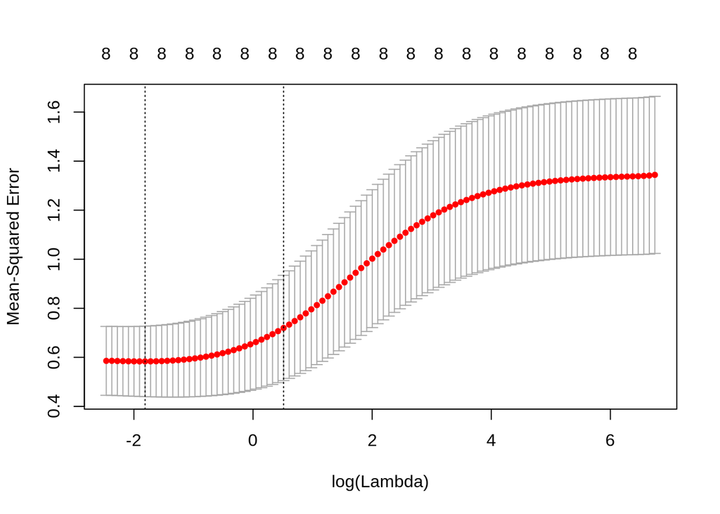

```r
plot(cvFit)
```

Now, let us get the best lambda.

```r
bestLam <- cvFit$lambda.min
bestLam
```

```
## [1] 0.1632045
```

```r
ridge.pred <- predict(ridge.mod, s = bestLam, type="coefficients")
summary(ridge.pred)
```

```
## 9 x 1 sparse Matrix of class "dgCMatrix", with 9 entries
##   i j            x
## 1 1 1 -0.056091546
## 2 2 1  0.445845445
## 3 3 1  0.583915970
## 4 4 1 -0.013738975
## 5 5 1  0.078751976
## 6 6 1  0.639056998
## 7 7 1 -0.003767270
## 8 8 1  0.069771811
## 9 9 1  0.002992739
```

```r
ridge.pred2 <- predict(ridge.mod, s = bestLam, type="response", newx = X[-train, ])
y_pred <- ridge.pred2
y_true <- Y[-train]
rss = sum((y_pred - y_true)^2)
rss
```

```
## [1] 25.12558
```

### Moving to LASSO now

```r
lasso.mod <- glmnet(X[train, ], Y[train], alpha = 1)
```

Let us now explore the model returned by glmnet.

```r
summary(lasso.mod)
```

```
##           Length Class     Mode
## a0         70    -none-    numeric
## beta      560    dgCMatrix S4
## df         70    -none-    numeric
## dim         2    -none-    numeric
## lambda     70    -none-    numeric
## dev.ratio  70    -none-    numeric
## nulldev     1    -none-    numeric
## npasses     1    -none-    numeric
## jerr        1    -none-    numeric
## offset      1    -none-    logical
## call        4    -none-    call
## nobs        1    -none-    numeric
```

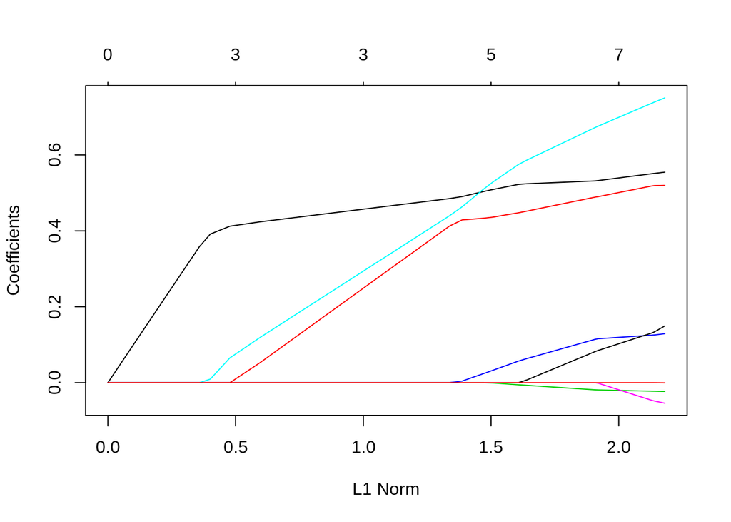

```r
plot(lasso.mod)
```

Getting the best lambda through cross validation.

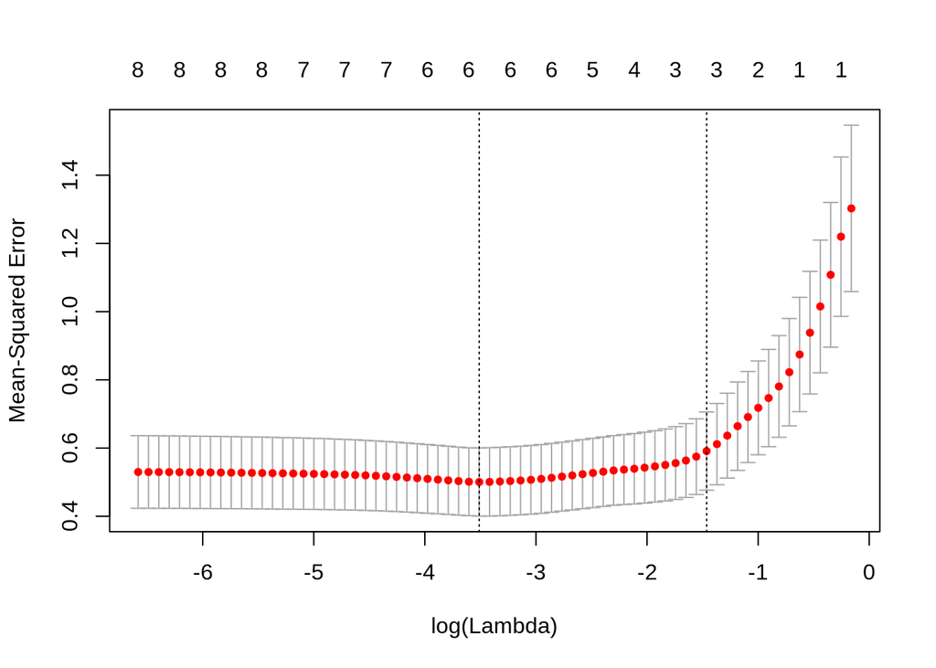

```r
cv.out = cv.glmnet(X[train, ], Y[train], alpha = 1)
plot(cv.out)
```

```r
lassoBestLam = cv.out$lambda.min
print(paste("The best lambda is", lassoBestLam))
```

```
## [1] "The best lambda is 0.02987846947126"
```

Getting the coefficients now for the best lambda.

```r
predict <- predict(lasso.mod, s = lassoBestLam, type = "coefficients")
predict
```

```
## 9 x 1 sparse Matrix of class "dgCMatrix"
##                       1
## (Intercept)  0.38067373
## lcavol       0.52988489
## lweight      0.48058418
## age         -0.01613112
## lbph         0.10303259
## svi          0.65309980
## lcp          .
## gleason      0.06540199
## pgg45        .
```

```r
lassoPredictTest <- predict(lasso.mod, s = lassoBestLam, type = "response", newx = X[-train, ])
lassoRss <- sum((lassoPredictTest - Y[-train])^2)
print(paste("The lasso RSS is: ",lassoRss))
```

```
## [1] "The lasso RSS is:  26.3238151326112"
```